# 1. Data exploration

```python
import matplotlib.pyplot as plt
import os
import pandas as pd
import numpy as np
```

### Περιγραφή Βήματος: Φόρτωση Δεδομένων

- Ορίζονται δύο path:
  - `./processed_data`: περιέχει τα πλήρη datasets.
  - `./events_data`: περιέχει δεδομένα από τις περιόδους των ειδικών γεγονότων.
- Αναζητούνται όλα τα `.csv` αρχεία στους αντίστοιχους φακέλους.
- Κάθε αρχείο διαβάζεται σε `pandas DataFrame` και αποθηκεύεται σε λεξικά:

Η χρήση των filenames ως κλειδιά επιτρέπει στο χρήστη να αναφέρεται εύκολα σε κάθε μετοχη με βάση το όνομά του και να συγκρίνει αποτελέσματα μεταξύ πλήρους και event περιόδου.

```python
full_data_path = "./processed_data"
event_data_path = "./events_data"

full_files  = [os.path.join(full_data_path, f)  for f in os.listdir(full_data_path)  if f.endswith(".csv")]
event_files = [os.path.join(event_data_path, f) for f in os.listdir(event_data_path) if f.endswith(".csv")]

full_datasets  = {os.path.splitext(os.path.basename(f))[0]: pd.read_csv(f) for f in full_files}
event_datasets = {os.path.splitext(os.path.basename(f))[0]: pd.read_csv(f) for f in event_files}

full_datasets
```

```
{'AAPL':             date        open        high         low       close   adj_close  \
 0     2010-01-04    6.422877    6.455077    6.391279    6.440331    6.440331
 1     2010-01-05    6.458086    6.487879    6.417459    6.451466    6.451466
 2     2010-01-06    6.451466    6.477045    6.342226    6.348846    6.348846
 3     2010-01-07    6.372319    6.379842    6.291066    6.337109    6.337109
 4     2010-01-08    6.328684    6.379844    6.291368    6.379241    6.379241
 ...          ...         ...         ...         ...         ...         ...
 3906  2024-12-24  255.209412  257.926422  255.009613  257.916443  257.916443
 3907  2024-12-25  255.209412  257.926422  255.009613  257.916443  257.916443
 3908  2024-12-26  257.906433  259.814331  257.347046  258.735504  258.735504
 3909  2024-12-27  257.546814  258.415894  252.782074  255.309296  255.309296
 3910  2024-12-30  251.952988  253.221588  250.474609  251.923019  251.923019

          volume  log_return_1d
 0     493729600            NaN
```

[output cut: 174 more lines]

### Προβολή Πληροφοριών και Περιγραφικών Στατιστικών

Σε αυτό το βήμα, πραγματοποιείται επανάληψη σε όλα τα datasets του λεξικού `full_datasets`. Για κάθε ticker:

- Εκτυπώνεται το όνομα του dataset.
- Παρουσιάζεται η βασική πληροφορία του DataFrame μέσω `df.info()`, όπως τύποι δεδομένων και αριθμός μη κενών τιμών.
- Ακολουθούν περιγραφικά στατιστικά με τη μέθοδο `df.describe()`, που περιλαμβάνει μέσους όρους, τυπική απόκλιση, ελάχιστες και μέγιστες τιμές κ.ά.
- Τέλος, εμφανίζεται μια γραμμή διαχωρισμού για καλύτερη αναγνωσιμότητα μεταξύ των εξόδων διαφορετικών tickers.

```python
for name, df in full_datasets.items():
    print(f"Dataset: {name}")
    print(df.info())
    print(df.describe())
    print("=" * 50)
```

```
Dataset: AAPL
<class 'pandas.core.frame.DataFrame'>
RangeIndex: 3911 entries, 0 to 3910
Data columns (total 8 columns):
 #   Column         Non-Null Count  Dtype
---  ------         --------------  -----
 0   date           3911 non-null   object
 1   open           3911 non-null   float64
 2   high           3911 non-null   float64
 3   low            3911 non-null   float64
 4   close          3911 non-null   float64
 5   adj_close      3911 non-null   float64
 6   volume         3911 non-null   int64
 7   log_return_1d  3910 non-null   float64
dtypes: float64(6), int64(1), object(1)
memory usage: 244.6+ KB
None
              open         high          low        close    adj_close  \
count  3911.000000  3911.000000  3911.000000  3911.000000  3911.000000
mean     67.454104    68.159332    66.788404    67.509747    67.509747
std      65.504283    66.187051    64.887123    65.582965    65.582965
min       5.789106     5.898344     5.725306     5.779476     5.779476
25%      17.469034    17.651609    17.316156    17.462426    17.462426
50%      35.336834    35.756618    34.964741    35.284367    35.284367
75%     126.388683   128.133263   124.979126   126.975742   126.975742
max     257.906433   259.814331   257.347046   258.735504   258.735504

             volume  log_return_1d
count  3.911000e+03    3910.000000
mean   2.289149e+08       0.000938
std    2.176302e+08       0.017249
min    2.323470e+07      -0.137708
25%    8.446475e+07      -0.006946
50%    1.394096e+08       0.000423
75%    3.068198e+08       0.009862
max    1.880998e+09       0.113157
==================================================
Dataset: AMD
<class 'pandas.core.frame.DataFrame'>
RangeIndex: 3911 entries, 0 to 3910
```

[output cut: 204 more lines]

```
25%      50.232057    50.697657    49.780180    50.263824    50.263824
50%      56.062630    56.425140    55.709324    56.091087    56.091087
75%      61.809517    62.125986    61.425821    61.815453    61.815453
max     123.127846   124.199379   122.744461   123.245819   123.245819

             volume  log_return_1d
count  3.911000e+03    3910.000000
mean   1.741632e+07       0.000253
std    9.253989e+06       0.015447
min    3.851300e+06      -0.130391
25%    1.118360e+07      -0.006808
50%    1.499170e+07       0.000000
75%    2.090775e+07       0.007634
max    1.180235e+08       0.119442
==================================================
```

### Οπτικοποίηση Τιμής Κλεισίματος ανά Μετοχή

Δημιουργούνται γραφήματα γραμμής για την τιμή κλεισίματος κάθε ticker σε όλο το dataset.

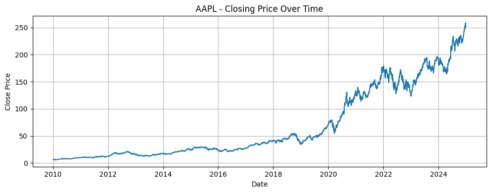

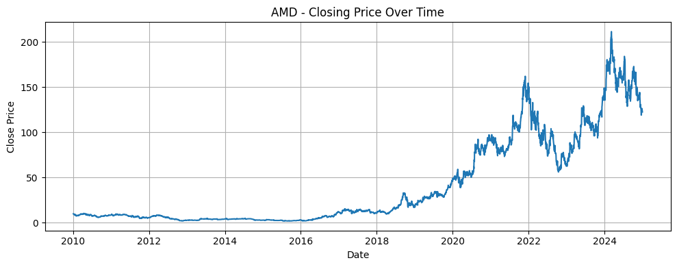

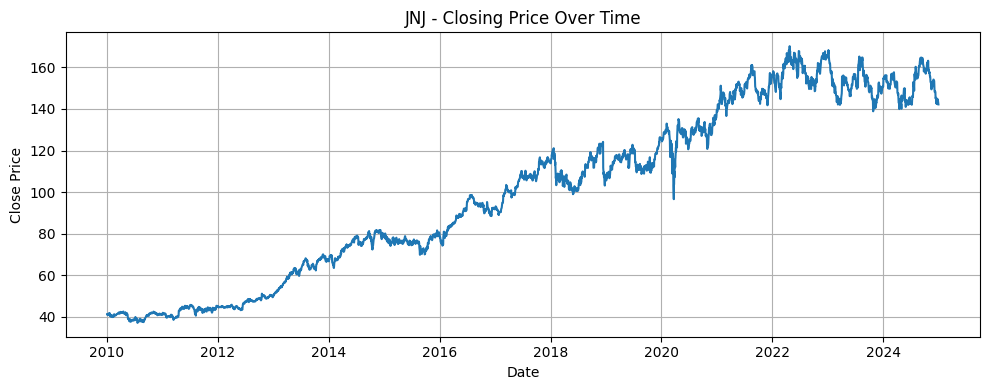

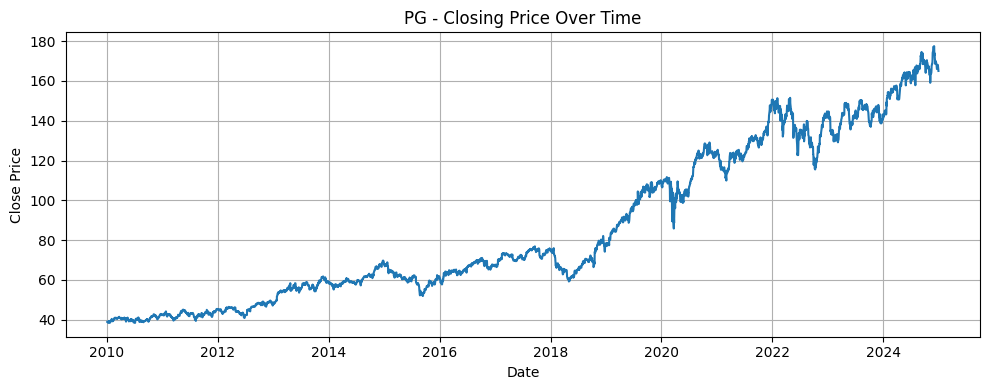

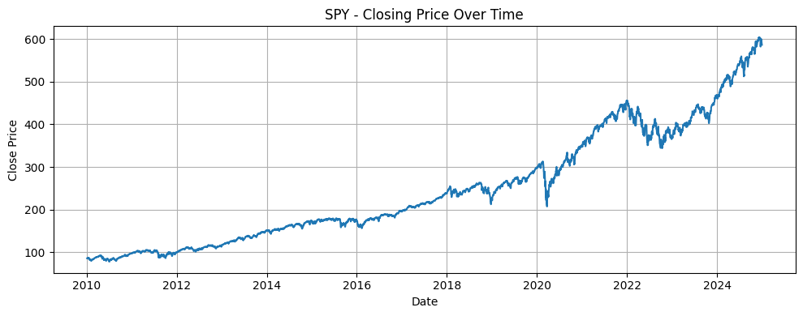

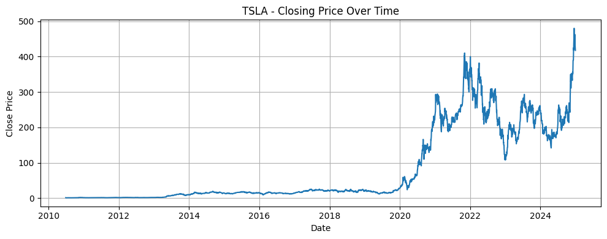

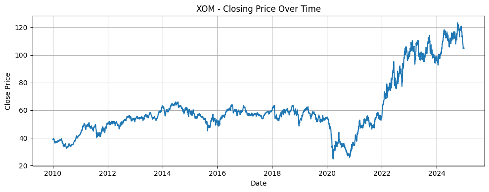

```python
for name, df in full_datasets.items():
    plt.figure(figsize=(10, 4))
    plt.plot(pd.to_datetime(df['date']), df['close'], label="Close Price")
    plt.title(f"{name} - Closing Price Over Time")
    plt.xlabel("Date")
    plt.ylabel("Close Price")
    plt.grid(True)
    plt.tight_layout()
    plt.savefig(f'./exploration/{name}.png', dpi=300, bbox_inches='tight')
    plt.show()
```

Δημιουργούνται γραφήματα γραμμής για την τιμή κλεισίματος κάθε event σε όλα τα dataset.

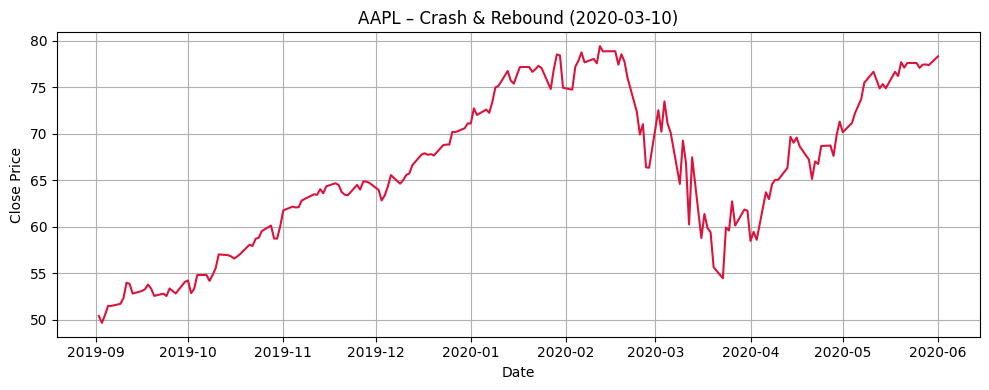

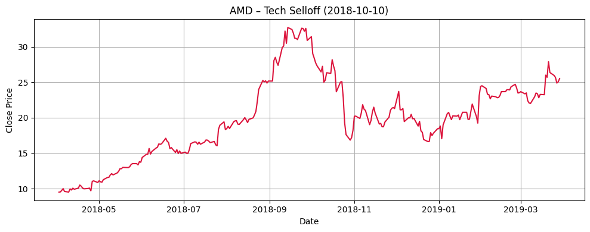

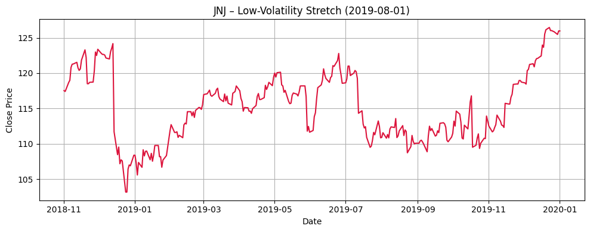

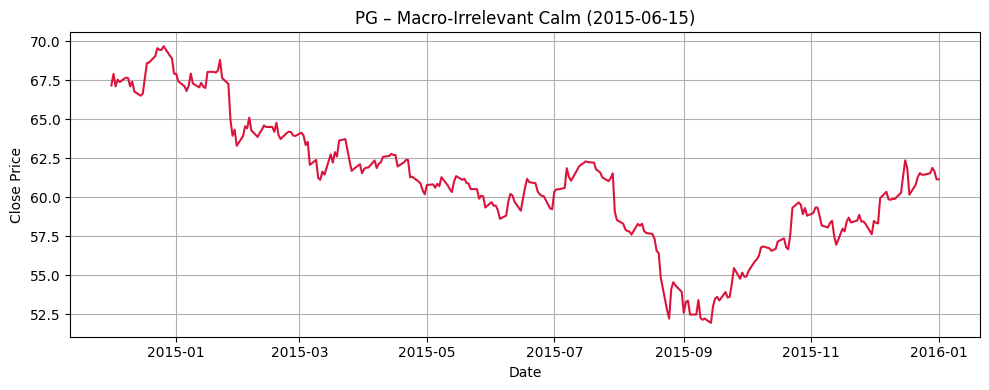

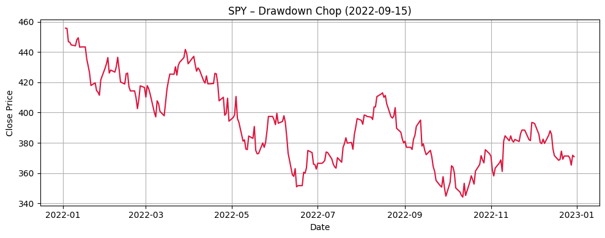

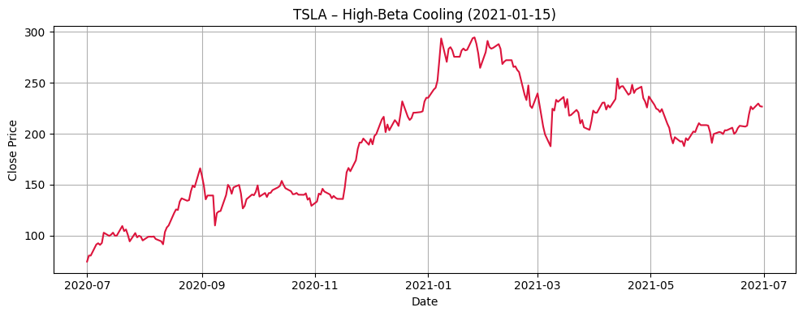

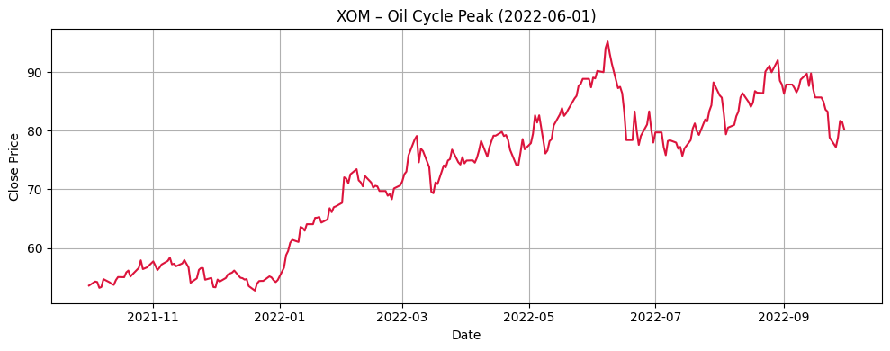

```python
event_titles = {
    "AAPL_cr": "AAPL – Crash & Rebound (2020-03-10)",
    "TSLA_hbc": "TSLA – High-Beta Cooling (2021-01-15)",
    "XOM_oil": "XOM – Oil Cycle Peak (2022-06-01)",
    "SPY_chop": "SPY – Drawdown Chop (2022-09-15)",
    "JNJ_lv": "JNJ – Low-Volatility Stretch (2019-08-01)",
    "AMD_sell": "AMD – Tech Selloff (2018-10-10)",
    "PG_calm": "PG – Macro-Irrelevant Calm (2015-06-15)"
}

for event_key, event_df in event_datasets.items():
    title = event_titles.get(event_key, event_key)
    event_df["date"] = pd.to_datetime(event_df["date"])
    plt.figure(figsize=(10, 4))
    plt.plot(event_df["date"], event_df["close"], label="Close Price", color='crimson')
    plt.title(title)
    plt.xlabel("Date")
    plt.ylabel("Close Price")
    plt.grid(True)
    plt.tight_layout()
    plt.savefig(f'./exploration/{title}.png', dpi=300, bbox_inches='tight')
    plt.show()
```

### Διαγράμματα κατανομής στήλης volume

Δημιουργούνται διαγράμματα κατανομής για την τιμή όγκου για κάθε dataset.

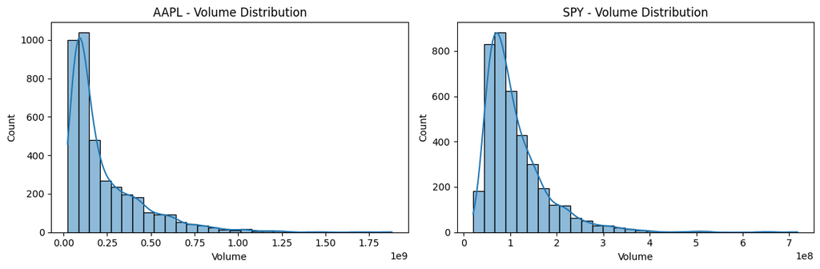

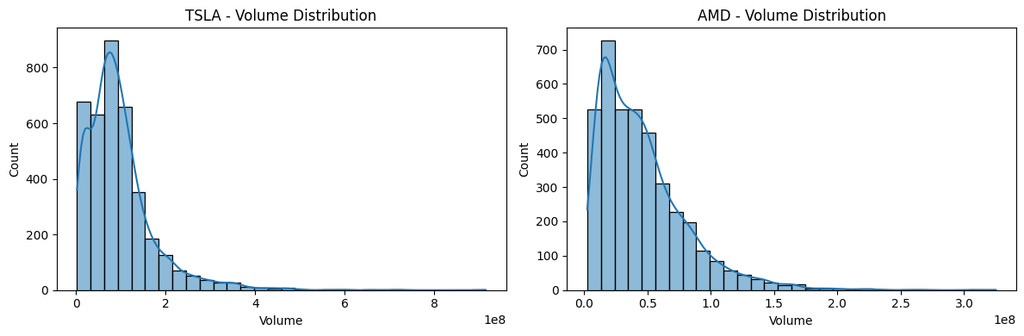

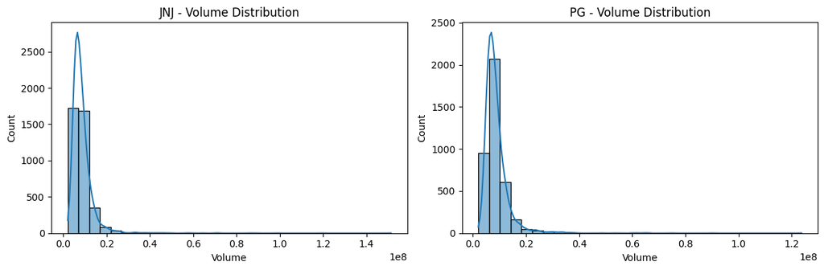

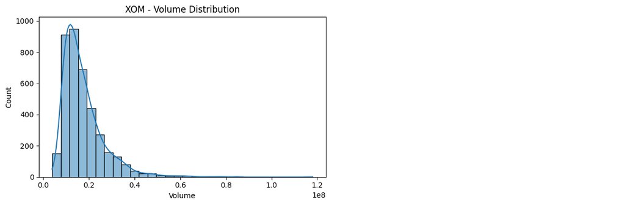

```python
custom_pairs = [
    ("AAPL", "SPY"),
    ("TSLA", "AMD"),
    ("JNJ", "PG"),
    ("XOM", None)
]

for i, (left, right) in enumerate(custom_pairs):
    plt.figure(figsize=(12, 4))
    df_left = full_datasets[left]
    plt.subplot(1, 2, 1)
    sns.histplot(df_left["volume"], bins=30, kde=True)
    plt.title(f"{left} - Volume Distribution")
    plt.xlabel("Volume")
    plt.ylabel("Count")
    if right:
        df_right = full_datasets[right]
        plt.subplot(1, 2, 2)
        sns.histplot(df_right["volume"], bins=30, kde=True)
        plt.title(f"{right} - Volume Distribution")
        plt.xlabel("Volume")
        plt.ylabel("Count")
    else:
        plt.subplot(1, 2, 2).axis("off")
    plt.tight_layout()
    plt.savefig(f"./exploration/volume_pair_{i+1}.png", dpi=300, bbox_inches='tight')
    plt.show()
```

### Από κοινού διαγράμματα μετοχών - event

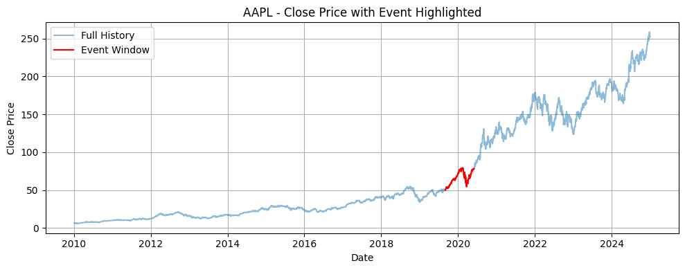

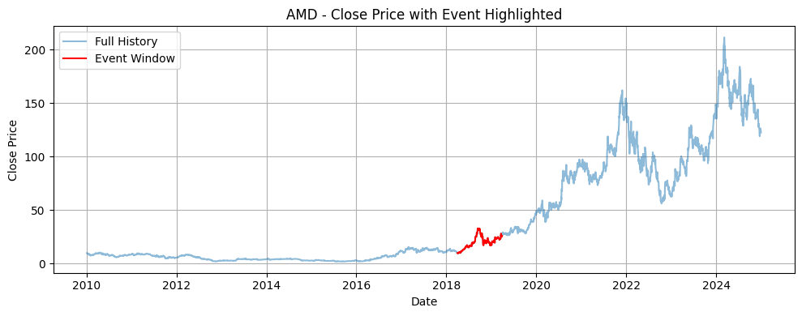

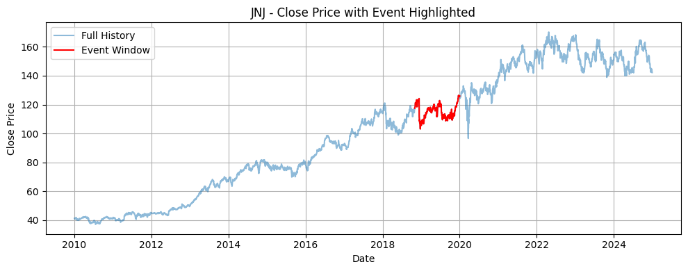

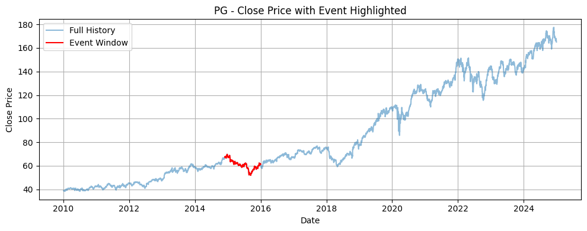

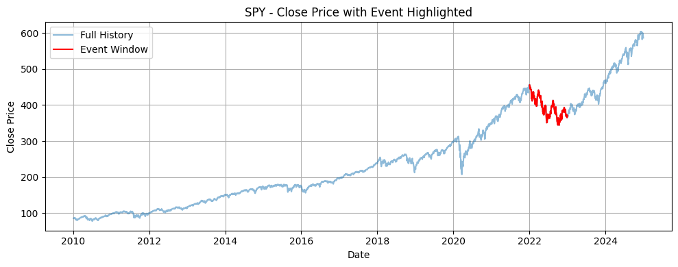

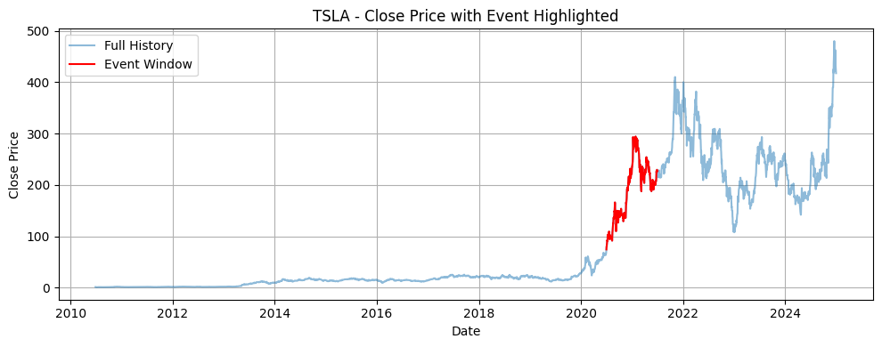

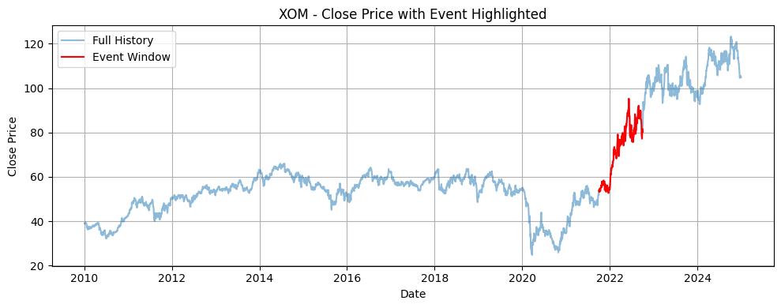

```python
for key in event_datasets:
    base_key = key.split("_")[0]
    event_df = event_datasets[key]
    full_df = full_datasets[base_key]

    plt.figure(figsize=(10, 4))
    plt.plot(pd.to_datetime(full_df["date"]), full_df["close"], alpha=0.5, label="Full History")
    plt.plot(pd.to_datetime(event_df["date"]), event_df["close"], color='red', label="Event Window")
    plt.title(f"{base_key} - Close Price with Event Highlighted")
    plt.xlabel("Date")
    plt.ylabel("Close Price")
    plt.legend()
    plt.grid(True)
    plt.tight_layout()
    plt.savefig(f"./exploration/{base_key} - Close Price with Event Highlighted", dpi=300, bbox_inches='tight')
    plt.show()
```

### Υπολογισμός Λογαριθμικών Αποδόσεων

Σε αυτό το βήμα πραγματοποιούνται βασικοί έλεγχοι και υπολογισμοί για κάθε dataset:

- Εμφανίζονται οι πρώτες 5 τιμές της `'close'` ως λίστα.
- Υπολογίζεται η λογαριθμική ημερήσια απόδοση (`log_return_1d`) ως: [ \log\left(\frac{P_t}{P_{t-1}}\right) = \log(P_t) - \log(P_{t-1}) ] χρησιμοποιώντας μετατόπιση (`shift(1)`).
- Τέλος, εκτυπώνεται ο αριθμός των έγκυρων (μη-NaN) τιμών λογαριθμικής απόδοσης, κάτι που επιβεβαιώνει την ποιότητα των δεδομένων για μεταγενέστερη ανάλυση.

```python
for name, df in  full_datasets.items():
    print(f"\n{name}")
    print("Close dtype:", df["close"].dtype)
    print("First 5 close values:", df["close"].head().tolist())
    df["log_return_1d"] = np.log(df["close"] / df["close"].shift(1))
    print("Valid log returns:", df["log_return_1d"].notna().sum())
```

```
AAPL
Close dtype: float64
First 5 close values: [6.440331, 6.451466, 6.348846, 6.337109, 6.379241]
Valid log returns: 3910

AMD
Close dtype: float64
First 5 close values: [9.7, 9.71, 9.57, 9.47, 9.43]
Valid log returns: 3910

JNJ
Close dtype: float64
First 5 close values: [41.324883, 40.845707, 41.17794, 40.884041, 41.024593]
Valid log returns: 3910

PG
Close dtype: float64
First 5 close values: [38.950233, 38.962971, 38.778172, 38.567879, 38.51688]
Valid log returns: 3910

SPY
Close dtype: float64
First 5 close values: [85.768433, 85.995468, 86.056068, 86.419296, 86.706886]
Valid log returns: 3910

TSLA
Close dtype: float64
First 5 close values: [1.592667, 1.588667, 1.464, 1.28, 1.28]
Valid log returns: 3784

XOM
Close dtype: float64
First 5 close values: [38.923954, 39.075932, 39.41367, 39.289822, 39.132221]
Valid log returns: 3910
```

[output not shown]

[output cut: 174 more lines]

### Πίνακας Συσχέτισης Λογαριθμικών Αποδόσεων

Δημιουργείται ο πίνακας συσχέτισης Pearson μεταξύ των ημερήσιων λογαριθμικών αποδόσεων όλων των assets:

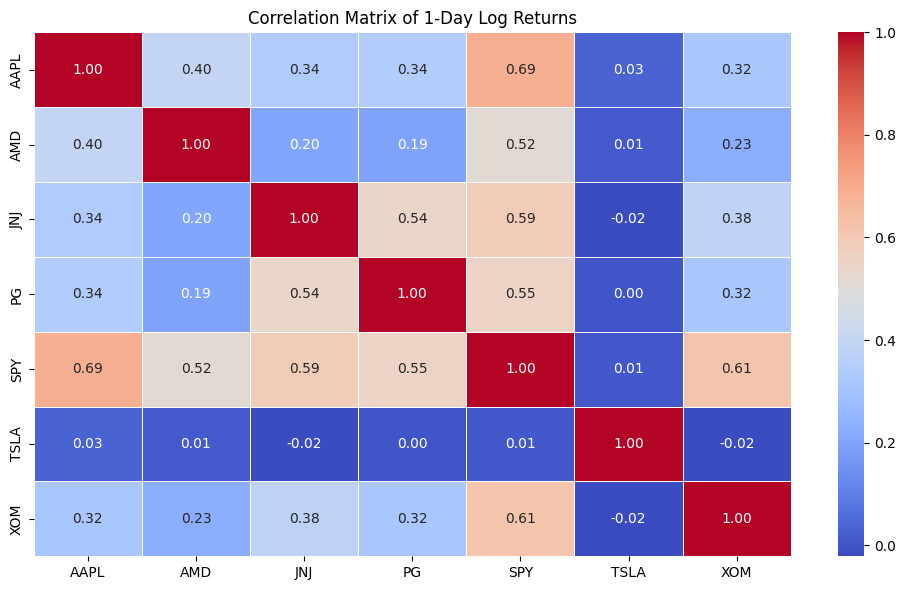

```python
returns = pd.DataFrame({
    ticker: df["log_return_1d"] for ticker, df in full_with_indicators.items()
}).dropna()

plt.figure(figsize=(10, 6))
sns.heatmap(returns.corr(), annot=True, cmap="coolwarm", fmt=".2f", linewidths=0.5)
plt.title("Correlation Matrix of 1-Day Log Returns")
plt.tight_layout()
plt.savefig(f'./exploration/correlation_matrix.png', dpi=300, bbox_inches='tight')

plt.show()
```